# Tutorial de knn en R: hoteles dataset

Flujo de trabajo paso a paso

Javier Álvarez Liébana https://javier-alvarez-liebana.github.io (Universidad Complutense de Madrid)  
2022-11-14

# Objetivo

El objetivo de este pequeño tutorial es saber aplicar un flujo de trabajo en el entorno `{tidymodels}` para poder implementar un algoritmo de clasificación knn en `R`, y las distintas **formas de validación**. Puedes ver más detalles y funcionalidades en la web oficial del paquete: https://www.tidymodels.org/

## Paquetes necesarios

Necesitaremos los siguientes paquetes

- **Análisis exploratorio numérico**: paquete `{skimr}`
- **Depuración y preprocesamiento**: paquete `{tidyverse}`
- **Modelización**: paquete `{tidymodels}` para modelos
- **Detección de outliers**: paquete `{outliers}`
- **Detección de festivos**: paquete `{timeDate}`

```r
# Borramos
rm(list = ls())

# Paquetes
library(skimr) # resumen numérico
library(tidymodels) # depuración datos
library(tidyverse) # modelos
library(outliers) # outliers
library(timeDate) # fechas
```

# Datos

Vamos ir a un **ejemplo real**, haciendo uso de un **dataset de reservas de hotel**

```r
hoteles_bruto <- read_csv(file = "./datos/hoteles.csv")
```

Los datos forman parte de un **conjunto de reservas de hotel** elaborado por Antonio et al., 2019 con 50 000 registros de reservas

📚 **Detalle de variables**: https://linkinghub.elsevier.com/retrieve/pii/S2352340918315191

## Análisis exploratorio inicial (numérico)

Antes de tomar ninguna decisión con los datos lo primero que deberíamos hacer es **echar un vistazo numérico** a cómo se comportan las variables. Dado que vamos a clasificar, lo primero que deberíamos observar es como se distribuyen los niveles de nuestra variable objetivo.

### Variables

Lo primero es conocer las variables

```r
glimpse(hoteles_bruto)
```

```
Rows: 50,000
Columns: 23
$ hotel                          <chr> "City_Hotel", "City_Hotel", "…
$ lead_time                      <dbl> 217, 2, 95, 143, 136, 67, 47,…
$ stays_in_weekend_nights        <dbl> 1, 0, 2, 2, 1, 2, 0, 0, 0, 2,…
$ stays_in_week_nights           <dbl> 3, 1, 5, 6, 4, 2, 2, 3, 4, 2,…
$ adults                         <dbl> 2, 2, 2, 2, 2, 2, 2, 0, 2, 2,…
$ children                       <chr> "none", "none", "none", "none…
$ meal                           <chr> "BB", "BB", "BB", "HB", "HB",…
$ country                        <chr> "DEU", "PRT", "GBR", "ROU", "…
$ market_segment                 <chr> "Offline_TA/TO", "Direct", "O…
$ distribution_channel           <chr> "TA/TO", "Direct", "TA/TO", "…
$ is_repeated_guest              <dbl> 0, 0, 0, 0, 0, 0, 0, 0, 0, 0,…
$ previous_cancellations         <dbl> 0, 0, 0, 0, 0, 0, 0, 0, 0, 0,…
$ previous_bookings_not_canceled <dbl> 0, 0, 0, 0, 0, 0, 0, 0, 0, 0,…
$ reserved_room_type             <chr> "A", "D", "A", "A", "F", "A",…
$ assigned_room_type             <chr> "A", "K", "A", "A", "F", "A",…
$ booking_changes                <dbl> 0, 0, 2, 0, 0, 0, 0, 0, 0, 0,…
$ deposit_type                   <chr> "No_Deposit", "No_Deposit", "…
$ days_in_waiting_list           <dbl> 0, 0, 0, 0, 0, 0, 0, 0, 0, 0,…
$ customer_type                  <chr> "Transient-Party", "Transient…
$ average_daily_rate             <dbl> 80.75, 170.00, 8.00, 81.00, 1…
$ required_car_parking_spaces    <chr> "none", "none", "none", "none…
$ total_of_special_requests      <dbl> 1, 3, 2, 1, 4, 1, 1, 1, 1, 1,…
$ arrival_date                   <date> 2016-09-01, 2017-08-25, 2016…
```

- `hotel`: tipo de hotel (urbano o resort)
- `lead_time`: número de días entre la reserva y la estancia.
- `stays_in_weekend_nights, stays_in_week_nights`: noches en fin de semana y entre semana
- `adults`: número de adultos
- `children`: ¿la reserva tiene niños?
- `meal`: régimen de comidas
- `country`: país de origen
- `market_segment`: segmento de mercado de la reserva
- `distribution_channel`: canal de distribución de la oferta
- `is_repeated_guest`: ¿repite como huésped?
- `previous_cancellations`: cancelaciones previas
- `previous_bookings_not_canceled`: reservas previas (no canceladas)
- `reserved_room_type, assigned_room_type`: tipo de habitación reservada/asignada
- `booking_changes`: cambios en la reserva
- `deposit_type`: tipo de depósito
- `days_in_waiting_list`: días en lista de espera
- `customer_type`: tipo de cliente
- `average_daily_rate`: tarifa media diaria
- `required_car_parking_spaces`: ¿parking?
- `total_of_special_requests`: número de requisitos especiales demandados
- `arrival_date`: fecha de llegada

### Balance la variable objetivo

El objetivo será **predecir si una reserva incluye niños/as o no**, por lo que `children` será nuestra variable objetivo. Primer paso: conocer cómo se **istribuyen los niveles de la objetivo** (es binaria)

```r
# Objetivo: predecir si la reserva viene o no con niños
hoteles_bruto %>%
  count(children) %>%
  mutate(porc = 100*n/sum(n))
```

```
# A tibble: 2 × 3
  children     n  porc
  <chr>    <int> <dbl>
1 children  4038  8.08
2 none     45962 91.9
```

### skim()

```r
# Resumen numérico
iris %>% skim()
```

Table 1: Data summary

| Name | Piped data |
| --- | --- |
| Number of rows | 150 |
| Number of columns | 5 |
| _______________________ |  |
| Column type frequency: |  |
| factor | 1 |
| numeric | 4 |
| ________________________ |  |
| Group variables | None |

**Variable type: factor**

| skim_variable | n_missing | complete_rate | ordered | n_unique | top_counts |
| --- | --- | --- | --- | --- | --- |
| Species | 0 | 1 | FALSE | 3 | set: 50, ver: 50, vir: 50 |

**Variable type: numeric**

| skim_variable | n_missing | complete_rate | mean | sd | p0 | p25 | p50 | p75 | p100 | hist |
| --- | --- | --- | --- | --- | --- | --- | --- | --- | --- | --- |
| Sepal.Length | 0 | 1 | 5.84 | 0.83 | 4.3 | 5.1 | 5.80 | 6.4 | 7.9 | ▆▇▇▅▂ |
| Sepal.Width | 0 | 1 | 3.06 | 0.44 | 2.0 | 2.8 | 3.00 | 3.3 | 4.4 | ▁▆▇▂▁ |
| Petal.Length | 0 | 1 | 3.76 | 1.77 | 1.0 | 1.6 | 4.35 | 5.1 | 6.9 | ▇▁▆▇▂ |
| Petal.Width | 0 | 1 | 1.20 | 0.76 | 0.1 | 0.3 | 1.30 | 1.8 | 2.5 | ▇▁▇▅▃ |

# Fase 1-2-3: muestreo-exploración-modificación

Lo primero que debemos hacer es examinar los datos y apuntar las **decisiones que deberíamos adoptar**. Por ejemplo:

- ¿Necesitamos **muestreo**? ¿De qué forma? ¿Podremos permitirnos crear esta vez un dataset de **validación**?
- ¿De qué **tipo** es cada variable? ¿Tenemos **problemas de codificación o rango**?
- ¿Cómo **afectan las predictoras** a los niveles de la variable objetivo?
- ¿Hay problemas de **dependencia** entre las variables?
- ¿Necesitamos **recategorizar** las variables? ¿Tenemos variables de **fecha**?
- ¿Tenemos **datos atípicos**? ¿Tenemos **datos ausentes**? ¿Cómo imputarlos?
- ¿Todas las variables son **numéricas** para poder aplicar la métrica?

La **filosofía** será la siguiente:

- modificaciones «estructurales» las hacemos fuera de la receta (modificando la base de datos)
- modificaciones más concretas para un algoritmo dentro de la receta (sin modificar la base de datos).

## Factores

Una de las primeras decisiones será dotar a las variables de su **tipología correcta**: debemos decidir es si las variables de tipo texto son **variables cualitativas** (factores) o meros id’s.

```r
hoteles_bruto %>%
  select(where(is.character)) %>%
  glimpse()
```

```
Rows: 50,000
Columns: 11
$ hotel                       <chr> "City_Hotel", "City_Hotel", "Res…
$ children                    <chr> "none", "none", "none", "none", …
$ meal                        <chr> "BB", "BB", "BB", "HB", "HB", "S…
$ country                     <chr> "DEU", "PRT", "GBR", "ROU", "PRT…
$ market_segment              <chr> "Offline_TA/TO", "Direct", "Onli…
$ distribution_channel        <chr> "TA/TO", "Direct", "TA/TO", "TA/…
$ reserved_room_type          <chr> "A", "D", "A", "A", "F", "A", "C…
$ assigned_room_type          <chr> "A", "K", "A", "A", "F", "A", "C…
$ deposit_type                <chr> "No_Deposit", "No_Deposit", "No_…
$ customer_type               <chr> "Transient-Party", "Transient", …
$ required_car_parking_spaces <chr> "none", "none", "none", "none", …
```

Todas las variables de tipo texto representan **categorías de una cualitativa** así que las convertimos todas ellas a factor (modificación estructural –> fuera de la receta)

```r
hoteles <-
  hoteles_bruto %>%
  mutate(across(where(is.character), as_factor))
hoteles
```

```
# A tibble: 50,000 × 23
   hotel  lead_…¹ stays…² stays…³ adults child…⁴ meal  country marke…⁵
   <fct>    <dbl>   <dbl>   <dbl>  <dbl> <fct>   <fct> <fct>   <fct>
 1 City_…     217       1       3      2 none    BB    DEU     Offlin…
 2 City_…       2       0       1      2 none    BB    PRT     Direct
 3 Resor…      95       2       5      2 none    BB    GBR     Online…
 4 Resor…     143       2       6      2 none    HB    ROU     Online…
 5 Resor…     136       1       4      2 none    HB    PRT     Direct
 6 City_…      67       2       2      2 none    SC    GBR     Online…
 7 Resor…      47       0       2      2 childr… BB    ESP     Direct
 8 City_…      56       0       3      0 childr… BB    ESP     Online…
 9 City_…      80       0       4      2 none    BB    FRA     Online…
10 City_…       6       2       2      2 childr… BB    FRA     Online…
# … with 49,990 more rows, 14 more variables:
#   distribution_channel <fct>, is_repeated_guest <dbl>,
#   previous_cancellations <dbl>,
#   previous_bookings_not_canceled <dbl>, reserved_room_type <fct>,
#   assigned_room_type <fct>, booking_changes <dbl>,
#   deposit_type <fct>, days_in_waiting_list <dbl>,
#   customer_type <fct>, average_daily_rate <dbl>, …
# ℹ Use `print(n = ...)` to see more rows, and `colnames()` to see all variable names
```

### Ordinales

¿Existe además alguna variable que pueda ser ordinal?

La variable `meal` si sigue una jerarquía: `SC` (sin nada) < `BB` (Bed & Breakfast) < `HB` (Half board, media pensión) < `FB` (Full board, pensión completa). Además tenemos un nivel para los desconocidos llamado `Undefined`

```r
hoteles %>%
  count(meal) %>%
  mutate(porc = 100*n/sum(n))
```

```
# A tibble: 5 × 3
  meal          n   porc
  <fct>     <int>  <dbl>
1 BB        38316 76.6
2 HB         6399 12.8
3 SC         4494  8.99
4 Undefined   580  1.16
5 FB          211  0.422
```

Por ello convertiremos `meal` a cualitativa pero ordinal.

```r
hoteles <-
  hoteles %>%
  mutate(meal = factor(meal, levels = c("Undefined", "SC", "BB", "HB", "FB"),
                       ordered = TRUE))
```

Esto nos permitirá hacer **operaciones asociadas a una jerarquía** como comparar registros

```r
hoteles %>%
  group_by(meal < "HB") %>% #<<
  count() %>%
  ungroup()
```

```
# A tibble: 2 × 2
  `meal < "HB"`     n
  <lgl>         <int>
1 FALSE          6610
2 TRUE          43390
```

## Variables cuali

Una vez convertidas en cualitativas analicemos cada una de ellas. La idea básica es la siguiente: ver que peso suponen cada nivel en las variables, y además, ver como **afectan los niveles a la variable objetivo**.

### Variable hotel

La variable `hotel` es **binaria**: urbanos vs resort (60% vs 40% aprox)

```r
hoteles %>%
  count(hotel, sort = TRUE) %>%
  mutate(porc = 100*n/sum(n))
```

```
# A tibble: 2 × 3
  hotel            n  porc
  <fct>        <int> <dbl>
1 City_Hotel   30752  61.5
2 Resort_Hotel 19248  38.5
```

Parece además que cuando hay **niños en la reserva** se opta ligeramente **más por los resort**, pero no de forma desproporcionada.

```r
hoteles %>%
  group_by(hotel) %>%
  count(children) %>%
  mutate(porc = 100*n/sum(n)) %>%
  ungroup()
```

```
# A tibble: 4 × 4
  hotel        children     n  porc
  <fct>        <fct>    <int> <dbl>
1 City_Hotel   none     28383 92.3
2 City_Hotel   children  2369  7.70
3 Resort_Hotel none     17579 91.3
4 Resort_Hotel children  1669  8.67
```

### Variable meal

La variable `meal` toma **5 modalidades**: quizás para algunos algoritmos haga falta reagrupar niveles (por ejemplo `Undefined` con `SC`)

```r
hoteles %>%
  count(meal, sort = TRUE) %>%
  mutate(porc = 100*n/sum(n))
```

```
# A tibble: 5 × 3
  meal          n   porc
  <ord>     <int>  <dbl>
1 BB        38316 76.6
2 HB         6399 12.8
3 SC         4494  8.99
4 Undefined   580  1.16
5 FB          211  0.422
```

Parece que **cuando hay niños** en la reserva hay el **doble de reservas con pensión completa**: aunque haya pocos registros de `meal = "FB"` pueden ser determinantes. El 11% de la reservas sin niños van sin nada, mientras que solo el 3% de las reservas con niños.

```r
hoteles %>%
  group_by(meal) %>%
  count(children) %>%
  mutate(porc = 100*n/sum(n)) %>%
  ungroup()
```

```
# A tibble: 10 × 4
   meal      children     n  porc
   <ord>     <fct>    <int> <dbl>
 1 Undefined none       548 94.5
 2 Undefined children    32  5.52
 3 SC        none      4388 97.6
 4 SC        children   106  2.36
 5 BB        none     35071 91.5
 6 BB        children  3245  8.47
 7 HB        none      5782 90.4
 8 HB        children   617  9.64
 9 FB        none       173 82.0
10 FB        children    38 18.0
```

```r
hoteles %>%
  group_by(children) %>%
  count(meal) %>%
  mutate(porc = 100*n/sum(n)) %>%
  ungroup()
```

```
# A tibble: 10 × 4
   children meal          n   porc
   <fct>    <ord>     <int>  <dbl>
 1 none     Undefined   548  1.19
 2 none     SC         4388  9.55
 3 none     BB        35071 76.3
 4 none     HB         5782 12.6
 5 none     FB          173  0.376
 6 children Undefined    32  0.792
 7 children SC          106  2.63
 8 children BB         3245 80.4
 9 children HB          617 15.3
10 children FB           38  0.941
```

### Variable country

La variable `country` toma **155 modalidades** pero tan solo **21 modalidades aparecen en más del 0.5% de registros** (una de ellas es NULL): quizás sea más práctico reagrupar niveles de esos países (representan juntos aprox el 10% del total).

```r
hoteles %>%
  count(country, sort = TRUE) %>%
  mutate(porc = 100*n/sum(n), cumul = cumsum(porc))
```

```
# A tibble: 155 × 4
   country     n  porc cumul
   <fct>   <int> <dbl> <dbl>
 1 PRT     14046 28.1   28.1
 2 GBR      6405 12.8   40.9
 3 FRA      5627 11.3   52.2
 4 ESP      4298  8.60  60.8
 5 DEU      4047  8.09  68.8
 6 IRL      1691  3.38  72.2
 7 ITA      1607  3.21  75.4
 8 BEL      1250  2.5   77.9
 9 NLD      1123  2.25  80.2
10 USA      1059  2.12  82.3
# … with 145 more rows
# ℹ Use `print(n = ...)` to see more rows
```

Aunque hay países que representa muy poco de los datos, parece que **algunos son más propensos a reservas con niños**, así que quizás una idea pueda ser decidir no solo por peso sino por % de niños, para que aprenda más de los 1’s que de los 0’s.

```r
hoteles %>%
  group_by(country) %>% count(children) %>%
  mutate(porc_children = 100*n/sum(n)) %>%
  ungroup()
```

```
# A tibble: 237 × 4
   country children     n porc_children
   <fct>   <fct>    <int>         <dbl>
 1 DEU     none      3863         95.5
 2 DEU     children   184          4.55
 3 PRT     none     12895         91.8
 4 PRT     children  1151          8.19
 5 GBR     none      5997         93.6
 6 GBR     children   408          6.37
 7 ROU     none       216         88.5
 8 ROU     children    28         11.5
 9 ESP     none      3824         89.0
10 ESP     children   474         11.0
# … with 227 more rows
# ℹ Use `print(n = ...)` to see more rows
```

Reminder: con estos análisis no vamos a eliminar registros (al menos no de manera general), solo decidir si recategorizamos/reagrupamos categorías. Esto además es **crucial** en el k-vecinos ya que **por cada variable cuali de N modalidades, deberemos luego crear N-1 dummys** asociadas.

### Variable market_segment

La variable `market_segment` toma **7 modalidades** aunque algunas representan menos del 1% del total.

```r
hoteles %>%
  count(market_segment, sort = TRUE) %>%
  mutate(porc = 100*n/sum(n), cumul = cumsum(porc))
```

```
# A tibble: 7 × 4
  market_segment     n   porc cumul
  <fct>          <int>  <dbl> <dbl>
1 Online_TA      23760 47.5    47.5
2 Offline_TA/TO  10604 21.2    68.7
3 Direct          7131 14.3    83.0
4 Groups          5124 10.2    93.2
5 Corporate       2832  5.66   98.9
6 Complementary    427  0.854  99.8
7 Aviation         122  0.244 100
```

Fíjate que aunque `market_segment = "Aviation"` representa muy pocos registros, el 100% son sin niños (casi similar con `market_segment = "Corporate"` y `market_segment = "Groups"`)

```r
hoteles %>%
  group_by(market_segment) %>%
  count(children) %>%
  mutate(porc = 100*n/sum(n)) %>%
  ungroup()
```

```
# A tibble: 13 × 4
   market_segment children     n    porc
   <fct>          <fct>    <int>   <dbl>
 1 Offline_TA/TO  none     10202  96.2
 2 Offline_TA/TO  children   402   3.79
 3 Direct         none      6138  86.1
 4 Direct         children   993  13.9
 5 Online_TA      none     21227  89.3
 6 Online_TA      children  2533  10.7
 7 Corporate      none      2799  98.8
 8 Corporate      children    33   1.17
 9 Groups         none      5084  99.2
10 Groups         children    40   0.781
11 Aviation       none       122 100
12 Complementary  none       390  91.3
13 Complementary  children    37   8.67
```

### Variable distribution_channel

La variable `distribution_channel` toma **5 modalidades** pero solo **3 de ellas agrupan ya más del 99%** de los registros.

```r
hoteles %>%
  count(distribution_channel, sort = TRUE) %>%
  mutate(porc = 100*n/sum(n),
         cumul = cumsum(porc))
```

```
# A tibble: 5 × 4
  distribution_channel     n   porc cumul
  <fct>                <int>  <dbl> <dbl>
1 TA/TO                38349 76.7    76.7
2 Direct                8083 16.2    92.9
3 Corporate             3459  6.92   99.8
4 GDS                    108  0.216 100.
5 Undefined                1  0.002 100
```

Fíjate que de `distribution_channel = "Undefined"` y `distribution_channel = "GDS"` representan **muy pocos registros**, y todos con una sola modalidad en la objetivo (pero solo pesan el 0.2% de los datos)

```r
hoteles %>%
  group_by(distribution_channel) %>%
  count(children) %>%
  mutate(porc = 100*n/sum(n)) %>%
  ungroup()
```

```
# A tibble: 8 × 4
  distribution_channel children     n   porc
  <fct>                <fct>    <int>  <dbl>
1 TA/TO                none     35388  92.3
2 TA/TO                children  2961   7.72
3 Direct               none      7045  87.2
4 Direct               children  1038  12.8
5 Corporate            none      3421  98.9
6 Corporate            children    38   1.10
7 GDS                  none       108 100
8 Undefined            children     1 100
```

### Variable reserved_room_type

La variable `reserved_room_type` toma **9 modalidades** (no nos especifican si hay jerarquía) pero **solo 5 de ellas tienen un peso superior al 1%** de los registros.

```r
hoteles %>%
  count(reserved_room_type, sort = TRUE) %>%
  mutate(porc = 100*n/sum(n),
         cumul = cumsum(porc))
```

```
# A tibble: 9 × 4
  reserved_room_type     n   porc cumul
  <fct>              <int>  <dbl> <dbl>
1 A                  34889 69.8    69.8
2 D                   8675 17.4    87.1
3 E                   3096  6.19   93.3
4 F                   1299  2.60   95.9
5 G                    899  1.80   97.7
6 B                    488  0.976  98.7
7 C                    417  0.834  99.5
8 H                    235  0.47  100.
9 L                      2  0.004 100
```

Fíjate que `reserved_room_type` será **tremendamente importante**: si la habitación es de tipo F, el 47% viene con niños (frente al 8% global), del 70% incluso si es de tipo C

```r
hoteles %>%
  group_by(reserved_room_type) %>%
  count(children) %>%
  mutate(porc = 100*n/sum(n)) %>%
  ungroup()
```

```
# A tibble: 17 × 4
   reserved_room_type children     n   porc
   <fct>              <fct>    <int>  <dbl>
 1 A                  none     33364  95.6
 2 A                  children  1525   4.37
 3 D                  none      8210  94.6
 4 D                  children   465   5.36
 5 F                  none       677  52.1
 6 F                  children   622  47.9
 7 C                  none       125  30.0
 8 C                  children   292  70.0
 9 B                  none       353  72.3
10 B                  children   135  27.7
11 E                  none      2828  91.3
12 E                  children   268   8.66
13 G                  none       341  37.9
14 G                  children   558  62.1
15 H                  none        62  26.4
16 H                  children   173  73.6
17 L                  none         2 100
```

### Variable assigned_room_type

La variable `assigned_room_type` toma **10 modalidades** (no nos especifican si hay jerarquía) pero solo 7 de ellas tienen un peso superior al 1% de los registros.

```r
hoteles %>%
  count(assigned_room_type, sort = TRUE) %>%
  mutate(porc = 100*n/sum(n),
         cumul = cumsum(porc))
```

```
# A tibble: 10 × 4
   assigned_room_type     n   porc cumul
   <fct>              <int>  <dbl> <dbl>
 1 A                  27357 54.7    54.7
 2 D                  12577 25.2    79.9
 3 E                   3924  7.85   87.7
 4 F                   1839  3.68   91.4
 5 C                   1305  2.61   94.0
 6 G                   1185  2.37   96.4
 7 B                   1079  2.16   98.5
 8 H                    313  0.626  99.2
 9 I                    239  0.478  99.6
10 K                    182  0.364 100
```

Como sucedía antes `assigned_room_type` será tremendamente importante

Quizás pueda ser además interesante, al margen del tipo de habitación, ver que sucede cuando la **asignada es distinta de la reservada**.

```r
hoteles %>%
  mutate(same_room = as.character(reserved_room_type) == as.character(assigned_room_type)) %>%
  group_by(same_room) %>%
  count(children) %>%
  mutate(porc = 100*n/sum(n)) %>%
  ungroup()
```

```
# A tibble: 4 × 4
  same_room children     n  porc
  <lgl>     <fct>    <int> <dbl>
1 FALSE     none      8601 91.5
2 FALSE     children   794  8.45
3 TRUE      none     37361 92.0
4 TRUE      children  3244  7.99
```

No parece que influya significativamente

### Variable deposit_type

La variable `deposit_type` toma **3 modalidades** pero el 99.6% de los registros es la misma.

```r
hoteles %>%
  count(deposit_type, sort = TRUE) %>%
  mutate(porc = 100*n/sum(n), cumul = cumsum(porc))
```

```
# A tibble: 3 × 4
  deposit_type     n   porc cumul
  <fct>        <int>  <dbl> <dbl>
1 No_Deposit   49839 99.7    99.7
2 Refundable      92  0.184  99.9
3 Non_Refund      69  0.138 100
```

Además de ser **muy pocos** los registros que no sean `No_Deposit`, prácticamente su totalidad son **sin niños** (clase ya mayoritaria en los datos).

```r
hoteles %>%
  group_by(deposit_type) %>%
  count(children) %>%
  mutate(porc = 100*n/sum(n)) %>%
  ungroup()
```

```
# A tibble: 6 × 4
  deposit_type children     n  porc
  <fct>        <fct>    <int> <dbl>
1 No_Deposit   none     45803 91.9
2 No_Deposit   children  4036  8.10
3 Refundable   none        91 98.9
4 Refundable   children     1  1.09
5 Non_Refund   none        68 98.6
6 Non_Refund   children     1  1.45
```

### Variable customer_type

La variable `customer_type` toma **4 modalidades** pero **dos de ellas representan más del 95%** de los registros.

```r
hoteles %>%
  count(customer_type, sort = TRUE) %>%
  mutate(porc = 100*n/sum(n),
         cumul = cumsum(porc))
```

```
# A tibble: 4 × 4
  customer_type       n   porc cumul
  <fct>           <int>  <dbl> <dbl>
1 Transient       35343 70.7    70.7
2 Transient-Party 12430 24.9    95.5
3 Contract         1864  3.73   99.3
4 Group             363  0.726 100
```

El 88% de las reservas con niños son de tipo `"Transient"`

```r
hoteles %>%
  group_by(children) %>%
  count(customer_type) %>%
  mutate(porc = 100*n/sum(n)) %>%
  ungroup()
```

```
# A tibble: 8 × 4
  children customer_type       n   porc
  <fct>    <fct>           <int>  <dbl>
1 none     Transient-Party 12075 26.3
2 none     Transient       31779 69.1
3 none     Contract         1762  3.83
4 none     Group             346  0.753
5 children Transient-Party   355  8.79
6 children Transient        3564 88.3
7 children Contract          102  2.53
8 children Group              17  0.421
```

### Variable required_car_parking_spaces

La variable `required_car_parking_spaces` es binaria (muy desbalanceada).

```r
hoteles %>%
  count(required_car_parking_spaces, sort = TRUE) %>%
  mutate(porc = 100*n/sum(n),
         cumul = cumsum(porc))
```

```
# A tibble: 2 × 4
  required_car_parking_spaces     n  porc cumul
  <fct>                       <int> <dbl> <dbl>
1 none                        45019 90.0   90.0
2 parking                      4981  9.96 100
```

El % de las reservas con niños es el doble cuando hay parking solicitado.

```r
hoteles %>%
  group_by(children) %>%
  count(required_car_parking_spaces) %>%
  mutate(porc = 100*n/sum(n)) %>%
  ungroup()
```

```
# A tibble: 4 × 4
  children required_car_parking_spaces     n  porc
  <fct>    <fct>                       <int> <dbl>
1 none     none                        41708 90.7
2 none     parking                      4254  9.26
3 children none                         3311 82.0
4 children parking                       727 18.0
```

## Dependencia entre cuali

Más allá del análisis exploratorio numérico, podemos ejecutar un **contraste de independencia** (prueba $\chi^2$ de independencia) para tener mayor certeza de si la predictora es dependiente o no de la variable objetivo (si fuera independiente, no tendría sentido mantenerla)

```r
chisq.test(hoteles$children, hoteles$hotel)
```

```
    Pearson's Chi-squared test with Yates' continuity correction

data:  hoteles$children and hoteles$hotel
X-squared = 14.796, df = 1, p-value = 0.0001198
```

Si fijamos $\alpha = 0.05$ (nivel de significación), si p-valor < 0.05 deberíamos rechazar la **hipótesis nula de independencia** (bajo dicho nivel).

Podemos hacerlo con **todas las variables a la vez** enfrentándola a la objetivo, entendiendo que cada columna juega el rol de una lista si usamos las funciones del paquete `{purrr}`

```r
chisq <-
  tibble("variable" = hoteles %>% select(where(is.factor)) %>% names(),
         "p_value" = hoteles %>% select(where(is.factor)) %>%
           map_dbl(.f = function(x) { chisq.test(hoteles$children, x)$p.value}))
chisq %>% arrange(desc(p_value))
```

```
# A tibble: 11 × 2
   variable                      p_value
   <chr>                           <dbl>
 1 deposit_type                6.20e-  3
 2 hotel                       1.20e-  4
 3 country                     1.60e- 40
 4 meal                        4.23e- 55
 5 required_car_parking_spaces 1.22e- 70
 6 distribution_channel        3.17e-107
 7 customer_type               4.39e-145
 8 market_segment              8.40e-292
 9 children                    0
10 reserved_room_type          0
11 assigned_room_type          0
```

```r
chisq %>% filter(p_value > 0.05)
```

```
# A tibble: 0 × 2
# … with 2 variables: variable <chr>, p_value <dbl>
# ℹ Use `colnames()` to see all variable names
```

**No hay evidencia suficiente para decir que existe predictora independiente de la objetivo** (al 95% de confianza) según la prueba de independencia realizada

## Resumen de las cuali

Esta es mi propuesta para un preprocesamiento básico (via libre para mejorarlo y completarlo)

- `hotel` –> **no hacer nada**.
- `meal`: aunque haya pocos registros de `meal = "FB"`, parece que pueden ser determinantes –> **reagrupar “Undefined” con “SC” y dejar “FB”**.
- `country`: tan solo 21 de ellas aparecen en más del 0.5% de registros (una de ellas es NULL) –> **reagrupar niveles de países minoritarios** (representan juntos aprox el 10% del total) quedándonos con aquellos que superen en un mínimo de representatividad (más fino: incluir también los que sean más propensos que otros a reservas con niños).
- `market_segment`: algunas representan menos del 1% del total, aunque para `market_segment = "Aviation"` el 100% son sin niños (casi similar con `market_segment = "Corporate"` y `market_segment = "Groups"`) –> **agrupar los 3 junto con “complementary”** (pesan muy poco estos últimos) en un `"others"`.
- `distribution_channel`: solo 3 de ellas agrupan ya más del 99% de los registros –> **reagrupar “Corporate” (98.9% no children), “GDS” (100% no children) y “Undefined” (solo 1 dato)** en `"others"` (aprox. el 7% de los datos).
- `reserved_room_type`: solo 5 de ellas tienen un peso superior al 1% de los registros, si es de tipo **C, H o L** (juntas suman el 1.3% de los datos aprox.), con niños superan el 70% –> **reagrupamos las 3** en un `"others"`
- `assigned_room_type`: con el mismo razonamiento que antes podemos **reaagupar las categorías H-I-K** en `"others"`
- `deposit_type`: el 99.6% de registros es la misma –> muy poca varianza y además casi todos de esas clases minoritarias son de la clase mayoritaria de la objetivo –> **eliminar**
- `customer_type` –> **reagrupar “Transient” y “others”**
- `required_car_parking_spaces` –> **no hacer nada**

## Variables de fecha

Solo tenemos una `arrival_date`: ¿qué parte de la fecha exactamente influye más? ¿El año? ¿El mes? ¿El día como número en sí o el día de la semana? Tras extraer info la eliminaremos.

```r
library(lubridate)
hoteles <-
  hoteles %>%
  mutate(m_arr = month(arrival_date), y_arr = year(arrival_date),
         wday_arr = wday(arrival_date))

hoteles %>% group_by(y_arr) %>% count(children) %>%
  mutate(porc = 100*n/sum(n))
```

```
# A tibble: 6 × 4
# Groups:   y_arr [3]
  y_arr children     n  porc
  <dbl> <fct>    <int> <dbl>
1  2015 none      8623 93.9
2  2015 children   562  6.12
3  2016 none     22161 91.8
4  2016 children  1981  8.21
5  2017 none     15178 91.0
6  2017 children  1495  8.97
```

No parece que el año influya mucho (veremos si influyen los días festivos en sí)

Sí parece que los meses de julio, agosto y diciembre influye mucho al tener más niños –> podemos agrupar los meses en `"month_holy"` y `"month_no_holy"`

```r
hoteles %>%
  group_by(m_arr) %>%
  count(children) %>%
  mutate(porc = 100*n/sum(n))
```

```
# A tibble: 24 × 4
# Groups:   m_arr [12]
   m_arr children     n  porc
   <dbl> <fct>    <int> <dbl>
 1     1 none      2586 94.5
 2     1 children   150  5.48
 3     2 none      3261 91.5
 4     2 children   302  8.48
 5     3 none      4195 94.7
 6     3 children   237  5.35
 7     4 none      4022 92.4
 8     4 children   331  7.60
 9     5 none      4538 94.8
10     5 children   249  5.20
# … with 14 more rows
# ℹ Use `print(n = ...)` to see more rows
```

Además parece que los viernes, sábados y domingos hay más reservas con niños –> podemos agrupar los meses en `"weekend"` y `"workday"`

```r
hoteles %>%  group_by(wday_arr) %>%  count(children) %>%
  mutate(porc = 100*n/sum(n))
```

```
# A tibble: 14 × 4
# Groups:   wday_arr [7]
   wday_arr children     n  porc
      <dbl> <fct>    <int> <dbl>
 1        1 none      5768 91.5
 2        1 children   537  8.52
 3        2 none      7324 92.1
 4        2 children   628  7.90
 5        3 none      5777 92.7
 6        3 children   456  7.32
 7        4 none      6468 93.7
 8        4 children   432  6.26
 9        5 none      6969 92.3
10        5 children   579  7.67
11        6 none      7094 92.0
12        6 children   620  8.04
13        7 none      6562 89.3
14        7 children   786 10.7
```

## Variables numéricas

Para las numéricas el proceso será ligeramente diferente, ya que ya no toman modalidades, aunque la mayoría de ellas como veremos podrían funcionar tanto de cuanti como de cuali (recategorizadas)

### Variable lead_time

- `lead_time`: variable con una alta concentración a la izquierda (cola pesada a la derecha), con un máximo de días muy elevado.

```r
hoteles %>% summarise(min_lead = min(lead_time), max_lead = max(lead_time))
```

```
# A tibble: 1 × 2
  min_lead max_lead
     <dbl>    <dbl>
1        0      709
```

Quizas no tenga sentido tanto número de días (¡más de un año!) entre la reserva y la estancia –> todo lo que **supere 365, imputarle 366** (representan además el 1.35% solo)

```r
hoteles %>%
  count(lead_time > 365)
```

```
# A tibble: 2 × 2
  `lead_time > 365`     n
  <lgl>             <int>
1 FALSE             49326
2 TRUE                674
```

### Variable stays_in_weekend_nights

```r
hoteles %>%
  count(stays_in_weekend_nights, sort = TRUE) %>%
  mutate(porc = 100*n/sum(n), cumul = cumsum(porc))
```

```
# A tibble: 17 × 4
   stays_in_weekend_nights     n   porc cumul
                     <dbl> <int>  <dbl> <dbl>
 1                       0 21640 43.3    43.3
 2                       2 13840 27.7    71.0
 3                       1 13031 26.1    97.0
 4                       4   826  1.65   98.7
 5                       3   564  1.13   99.8
 6                       6    41  0.082  99.9
 7                       5    22  0.044  99.9
 8                       8    18  0.036 100.
 9                      10     4  0.008 100.
10                       7     2  0.004 100.
11                       9     2  0.004 100.
12                      12     2  0.004 100.
13                      13     2  0.004 100.
14                      14     2  0.004 100.
15                      16     2  0.004 100.
16                      18     1  0.002 100.
17                      19     1  0.002 100
```

### Variable stays_in_week_nights

- `stays_in_week_nights`: en realidad es una variable cualitativa más que cuantitativa, y a partir de 5 noches representa menos del 5% –> podríamos probar a **dejarla tal cual o recategorizarla en 7 categorías** (ninguna - 1 - 2 - 3 - 4 - 5 - más de 5)

```r
hoteles %>%
  count(stays_in_week_nights, sort = TRUE) %>%
  mutate(porc = 100*n/sum(n), cumul = cumsum(porc))
```

```
# A tibble: 31 × 4
   stays_in_week_nights     n   porc cumul
                  <dbl> <int>  <dbl> <dbl>
 1                    1 13619 27.2    27.2
 2                    2 12513 25.0    52.3
 3                    3  9161 18.3    70.6
 4                    5  4779  9.56   80.1
 5                    4  4020  8.04   88.2
 6                    0  3818  7.64   95.8
 7                    6   616  1.23   97.1
 8                   10   488  0.976  98.0
 9                    7   481  0.962  99.0
10                    8   303  0.606  99.6
# … with 21 more rows
# ℹ Use `print(n = ...)` to see more rows
```

### Variable adults

- `adults`: en realidad es una variable cualitativa más que cuantitativa –> podríamos probar a **dejarla tal cual o recategorizarla en 4 categorías** (ninguno - 1 - 2 - más de 2)

```r
hoteles %>% count(adults, sort = TRUE) %>%
  mutate(porc = 100*n/sum(n), cumul = cumsum(porc))
```

```
# A tibble: 5 × 4
  adults     n   porc cumul
   <dbl> <int>  <dbl> <dbl>
1      2 36271 72.5    72.5
2      1 10831 21.7    94.2
3      3  2675  5.35   99.6
4      0   194  0.388  99.9
5      4    29  0.058 100
```

### Variable is_repeated_guest

- `is_repeated_guest`: en realidad es **binaria** –> hay que convertirla a cualitativa (factor)

```r
hoteles %>%
  count(is_repeated_guest, sort = TRUE) %>%
  mutate(porc = 100*n/sum(n))
```

```
# A tibble: 2 × 3
  is_repeated_guest     n  porc
              <dbl> <int> <dbl>
1                 0 47840 95.7
2                 1  2160  4.32
```

```r
hoteles %>%
  group_by(is_repeated_guest) %>%
  count(children) %>%
  mutate(porc = 100*n/sum(n)) %>%
  ungroup()
```

```
# A tibble: 4 × 4
  is_repeated_guest children     n  porc
              <dbl> <fct>    <int> <dbl>
1                 0 none     43863 91.7
2                 0 children  3977  8.31
3                 1 none      2099 97.2
4                 1 children    61  2.82
```

### Variables previous_cancellations y previous_bookings_not_canceled

- `previous_cancellations`: el 99.238% son 0 (y la mayoría de 1, sin niños) –> **eliminar**
- `previous_bookings_not_canceled`: el 95.47% son 0, el 1.9% son 1 –> se podría probar a **dejarla tal cual o recategorizar en 3 categorías**

```r
hoteles %>% count(previous_cancellations == 0, sort = TRUE)
```

```
# A tibble: 2 × 2
  `previous_cancellations == 0`     n
  <lgl>                         <int>
1 TRUE                          49619
2 FALSE                           381
```

```r
hoteles %>% count(previous_bookings_not_canceled, sort = TRUE) %>%
  mutate(porc = 100*n/sum(n), cumul = cumsum(porc))
```

```
# A tibble: 57 × 4
   previous_bookings_not_canceled     n   porc cumul
                            <dbl> <int>  <dbl> <dbl>
 1                              0 47735 95.5    95.5
 2                              1   956  1.91   97.4
 3                              2   370  0.74   98.1
 4                              3   210  0.42   98.5
 5                              4   148  0.296  98.8
 6                              5   112  0.224  99.1
 7                              6    76  0.152  99.2
 8                              7    50  0.1    99.3
 9                              9    42  0.084  99.4
10                              8    39  0.078  99.5
# … with 47 more rows
# ℹ Use `print(n = ...)` to see more rows
```

### Variable booking_changes

- `booking_changes`: el 94.194% son 0 o 1 –> se podría probar a **dejarla numérica o recategorizar en 3 categorías**

```r
hoteles %>% count(booking_changes, sort = TRUE) %>%
  mutate(porc = 100*n/sum(n), cumul = cumsum(porc))
```

```
# A tibble: 19 × 4
   booking_changes     n   porc cumul
             <dbl> <int>  <dbl> <dbl>
 1               0 39823 79.6    79.6
 2               1  7274 14.5    94.2
 3               2  2018  4.04   98.2
 4               3   523  1.05   99.3
 5               4   212  0.424  99.7
 6               5    71  0.142  99.8
 7               6    31  0.062  99.9
 8               7    13  0.026  99.9
 9               8    11  0.022 100.
10               9     6  0.012 100.
11              10     4  0.008 100.
12              13     3  0.006 100.
13              15     3  0.006 100.
14              11     2  0.004 100.
15              17     2  0.004 100.
16              12     1  0.002 100.
17              16     1  0.002 100.
18              18     1  0.002 100.
19              21     1  0.002 100
```

#### Variable days_in_waiting_list

- `days_in_waiting_list`: el 98% de los registros son 0 (y de los que no son casi todos no tienen niños) –> **eliminar variable**

```r
hoteles %>% count(days_in_waiting_list, sort = TRUE) %>%
  mutate(porc = 100*n/sum(n), cumul = cumsum(porc))
```

```
# A tibble: 92 × 4
   days_in_waiting_list     n   porc cumul
                  <dbl> <int>  <dbl> <dbl>
 1                    0 49116 98.2    98.2
 2                   58   114  0.228  98.5
 3                   87    47  0.094  98.6
 4                   38    34  0.068  98.6
 5                   63    34  0.068  98.7
 6                  122    33  0.066  98.8
 7                   65    26  0.052  98.8
 8                  223    26  0.052  98.9
 9                   77    25  0.05   98.9
10                   44    22  0.044  99.0
# … with 82 more rows
# ℹ Use `print(n = ...)` to see more rows
```

### Variable average_daily_rate

- `average_daily_rate`: es la única numérica continua pero tiene **valores negativos o cero** (deberían ser estrictamente positivo) –> el 2.33% tiene **problemas de codificación o rango** que deberemos pasar a ausentes e imputarles un valores luego.

```r
hoteles %>%
  count(average_daily_rate <= 0) %>%
  mutate(porc = 100*n/sum(n))
```

```
# A tibble: 2 × 3
  `average_daily_rate <= 0`     n  porc
  <lgl>                     <int> <dbl>
1 FALSE                     48833 97.7
2 TRUE                       1167  2.33
```

### Variable total_of_special_requests

- `total_of_special_requests`: más del 96% son 0-1-2 –> se podría **dejar numérica o recategorizarla en 4 categorías**.

```r
hoteles %>%
  count(total_of_special_requests, sort = TRUE) %>%
  mutate(porc = 100*n/sum(n), cumul = cumsum(porc))
```

```
# A tibble: 6 × 4
  total_of_special_requests     n   porc cumul
                      <dbl> <int>  <dbl> <dbl>
1                         0 24493 49.0    49.0
2                         1 17234 34.5    83.5
3                         2  6679 13.4    96.8
4                         3  1358  2.72   99.5
5                         4   213  0.426 100.
6                         5    23  0.046 100
```

## Colinealidad

Por último, nos falta comprobar los **problemas de colinealidad** entre las predictoras numéricas. Podemos tratar las **numéricas por separado** (aunque tengamos muchas que en realidad hacen más de cuali que de cuanti)

```r
library(corrr)
cor_matrix <- hoteles %>% select(where(is.numeric)) %>% cor() %>% round(2)
cor_matrix
```

```
                               lead_time stays_in_weekend_nights
lead_time                           1.00                    0.19
stays_in_weekend_nights             0.19                    1.00
stays_in_week_nights                0.28                    0.51
adults                              0.14                    0.13
is_repeated_guest                  -0.15                   -0.10
previous_cancellations             -0.04                   -0.02
previous_bookings_not_canceled     -0.08                   -0.05
booking_changes                     0.09                    0.07
days_in_waiting_list                0.18                   -0.05
average_daily_rate                  0.02                    0.04
total_of_special_requests           0.04                    0.07
m_arr                               0.10                    0.03
y_arr                               0.11                    0.01
wday_arr                            0.05                   -0.14
                               stays_in_week_nights adults
lead_time                                      0.28   0.14
stays_in_weekend_nights                        0.51   0.13
stays_in_week_nights                           1.00   0.13
adults                                         0.13   1.00
is_repeated_guest                             -0.11  -0.21
previous_cancellations                        -0.03  -0.06
previous_bookings_not_canceled                -0.06  -0.15
booking_changes                                0.12  -0.07
days_in_waiting_list                           0.01  -0.01
average_daily_rate                             0.05   0.33
total_of_special_requests                      0.06   0.20
m_arr                                          0.03   0.04
y_arr                                          0.01   0.04
wday_arr                                      -0.01   0.06
                               is_repeated_guest
lead_time                                  -0.15
stays_in_weekend_nights                    -0.10
stays_in_week_nights                       -0.11
adults                                     -0.21
is_repeated_guest                           1.00
previous_cancellations                      0.25
previous_bookings_not_canceled              0.44
booking_changes                             0.00
days_in_waiting_list                       -0.02
```

[output cut: 80 more lines]

```
                               wday_arr
lead_time                          0.05
stays_in_weekend_nights           -0.14
stays_in_week_nights              -0.01
adults                             0.06
is_repeated_guest                 -0.05
previous_cancellations            -0.01
previous_bookings_not_canceled    -0.04
booking_changes                    0.01
days_in_waiting_list               0.01
average_daily_rate                 0.01
total_of_special_requests          0.01
m_arr                              0.00
y_arr                             -0.03
wday_arr                           1.00
```

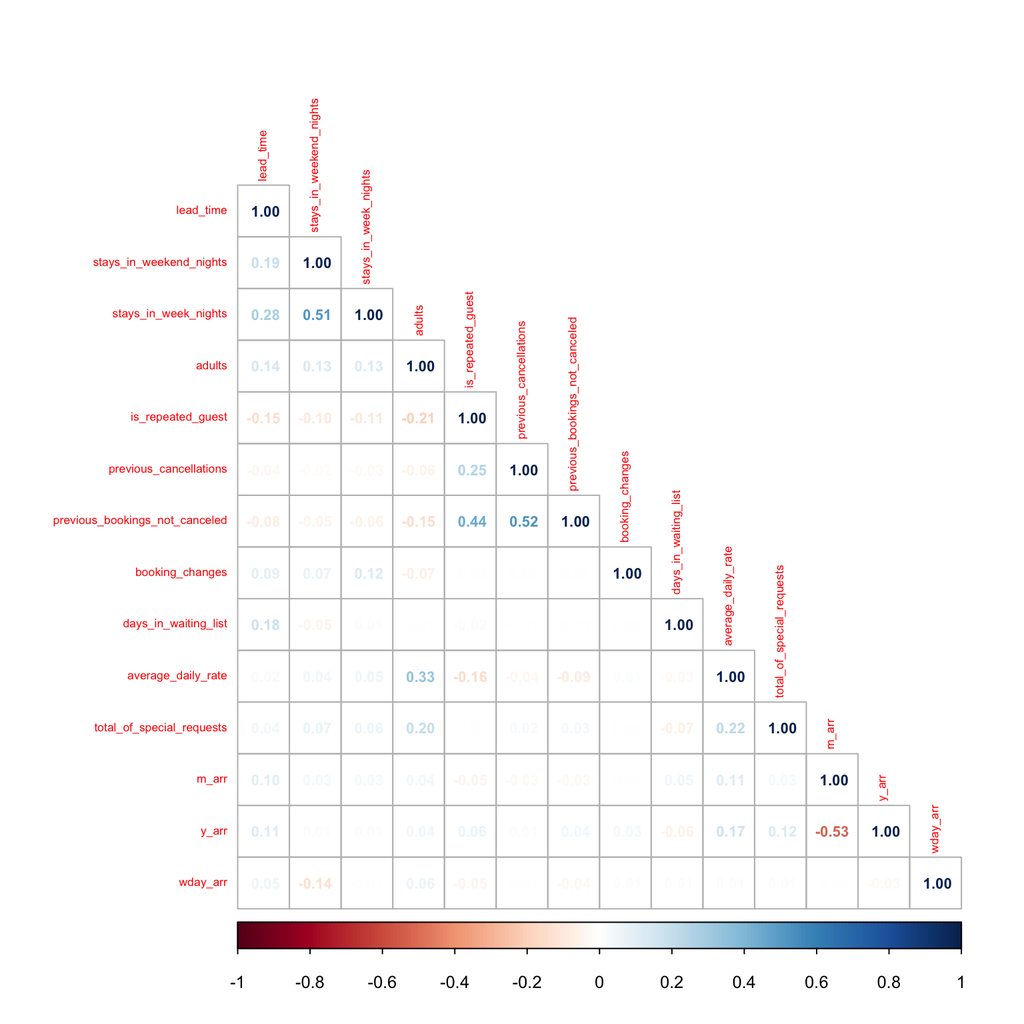

```r
library(corrplot)
cor_matrix %>%
  corrplot(method = "number", tl.cex = 0.55, number.cex = 0.7, type = "lower")
```

No parece existir una correlación elevada entre ninguna.

## Fase 3: modificación (fuera de la receta)

Con lo observado en la fase de exploración deberemos tomar **dos tipos decisiones**:

- las que afectan a la **base de datos en general**: pasar a factores, problemas de codificación o rango, variables que no aportan, creación de variables en general, etc
- las que afectan a un **algoritmo en concreto**: normalización para la métrica, recategorización, tratamiento de outliers/ausentes, dummyficación, etc.

Pero antes…¿hace falta **muestreo**? Parece que sí dado que tenemos muchas filas (al menos para hacer pruebas) –> muestreo **estratificado** (por ej., del 10%)

```r
# Muestreo del 10%
hoteles_sample <-
  hoteles_bruto %>%
  group_by(children) %>%
  slice_sample(prop = 0.10) %>%
  ungroup()
```

Tras ello procederemos a las **modificaciones estructurales** (la tabla está incorrectamente codificada)

```r
# Convertir a cuali
hoteles_sample <-
  hoteles_sample %>%
  mutate(across(where(is.character), as_factor)) %>%
  mutate(meal = factor(meal, levels = c("Undefined", "SC", "BB", "HB", "FB"),
                       ordered = TRUE))

# Modificaciones de variables existentes
hoteles_sample <-
  hoteles_sample %>%
  mutate(lead_time = ifelse(lead_time > 365, 366, lead_time),
         average_daily_rate = ifelse(average_daily_rate < 0 | is.na(average_daily_rate), NA, average_daily_rate),
         is_repeated_guest = as_factor(is_repeated_guest))
```

## Fase 3: modificación (dentro de la receta)

### Partición

#### Test vs lo demás

Antes de nada deberemos realizar nuestras particiones, y primero dividiremos en **test y lo demás**, con `initial_split()`, teniendo 10% en test y 90% en todo lo demás

```r
# Partición 10% de test
hoteles_split <- initial_split(hoteles_sample, strata = children, prop = 0.9)
hoteles_split
```

```
<Analysis/Assess/Total>
<4499/500/4999>
```

Fíjate que en `hoteles_split` solo tenemos las instrucciones. Vamos a aplicarlas

```r
# Aplicamos partición
hoteles_train <- training(hoteles_split)
hoteles_test <- testing(hoteles_split)
```

Tras ello nunca está de más comprobar que efectivamente lo ha realizado de manera estratificada

```r
# Comprobamos estratos
hoteles_train %>% count(children) %>% mutate(porc = 100 * n / sum(n))
```

```
# A tibble: 2 × 3
  children     n  porc
  <fct>    <int> <dbl>
1 children   364  8.09
2 none      4135 91.9
```

```r
hoteles_test %>% count(children) %>% mutate(porc = 100 * n / sum(n))
```

```
# A tibble: 2 × 3
  children     n  porc
  <fct>    <int> <dbl>
1 children    39   7.8
2 none       461  92.2
```

#### Validación

Tras ello usamos `validation_split()` para **dividir en train-validación** lo que teníamos en `hoteles_train` (75% del 90% nos quedaría 67.5% en train vs 22.5% en validación y 10% que teníamos en test)

```r
# Validación
hoteles_val <- validation_split(hoteles_train, strata = children,
                                prop = 0.75)
hoteles_val
```

```
# Validation Set Split (0.75/0.25)  using stratification
# A tibble: 1 × 2
  splits              id
  <list>              <chr>
1 <split [3374/1125]> validation
```

De nuevo en `hoteles_val` solo tenemos las futuras instrucciones. Fíjate que de nuevo lo hacemos estratificado con `strata = children`

### Roles

Tras las particiones, el primer paso es **definir la receta**, indicándole el conjunto donde tenemos validación y train, y enfrentar `children` con todas. Después lo que haremos será **asignar posibles roles** que nos puedan diferencias las acciones entre las variables

```r
# Receta
hoteles_rec <-
  # Fórmula y datos
  recipe(data = hoteles_train, children ~ .)%>%
  # Roles
  add_role(contains("date"), new_role = "date") %>%
  add_role(where(is.factor), new_role = "cuali") %>%
  add_role(where(is.numeric), new_role = "cuanti") %>%
  add_role(c(hotel, required_car_parking_spaces, is_repeated_guest), new_role = "binary") %>%
  add_role(where(is.numeric) & !average_daily_rate, new_role = "maybe_cuali")
```

### Eliminar variables

Habíamos decidido que había variable que no queríamos usar así que lo primero es eliminarlas para no acumularlas en el proceso

```r
# Receta
hoteles_rec <-
  hoteles_rec %>%
  step_rm(c(deposit_type, days_in_waiting_list, previous_cancellations))
```

### Fechas

Con `step_date()` podemos indicarle directamente que extraiga de la fecha los elementos que le pidamos (en nuestro caso mes, día de la semana y año). Además con `listHolidays()` del paquete `{timeDate}` seleccionaremos festivos relevantes internacionalmente, y con `step_holiday()` marcaremos las fechas que lo sean. Tras ello eliminaremos la fecha original con `step_rm()`.

```r
library(timeDate)
# Receta
hoteles_rec <-
  hoteles_rec %>%
  step_date(arrival_date, features = c("month", "dow", "year")) %>%
  step_holiday(arrival_date,
               holidays = c(listHolidays("\\Mary"), listHolidays("\\Easter"),
                            listHolidays("\\Christ"), "NewYearsDay")) %>%
  # Eliminamos la variable
  step_rm(arrival_date)
```

Prueba a jugar con `listHolidays()` y las vacaciones que nos ofrecen (en global o para distintos países)

```r
listHolidays()
```

```
  [1] "Advent1st"                "Advent2nd"
  [3] "Advent3rd"                "Advent4th"
  [5] "AllSaints"                "AllSouls"
  [7] "Annunciation"             "Ascension"
  [9] "AshWednesday"             "AssumptionOfMary"
 [11] "BirthOfVirginMary"        "BoxingDay"
 [13] "CACanadaDay"              "CACivicProvincialHoliday"
 [15] "CALabourDay"              "CaRemembranceDay"
 [17] "CAThanksgivingDay"        "CAVictoriaDay"
 [19] "CelebrationOfHolyCross"   "CHAscension"
 [21] "CHBerchtoldsDay"          "CHConfederationDay"
 [23] "CHKnabenschiessen"        "ChristmasDay"
 [25] "ChristmasEve"             "ChristTheKing"
 [27] "CHSechselaeuten"          "CorpusChristi"
 [29] "DEAscension"              "DEChristmasEve"
```

[output cut: 43 more lines]

### Outliers

En este caso yo voy a **detectar outliers a lo bruto**: detectando por la media e imputando por la media, pero solo de `has_role("cuanti")`, para no incluir a las binarias. Las cuali por la moda en caso de haber ausentes. Queda en tus manos mejorar esto.

```r
library(outliers)
# Receta
hoteles_rec <-
  hoteles_rec %>%
  # Detectar outliers
  step_mutate(across(where(is.numeric), function(x) { ifelse(abs(scores(x, type = "z")) > 2.5 & !is.na(x), NA, x) })) %>%
  # Imputar ausentes
  step_impute_mean(has_role("cuanti")) %>%
  step_impute_mode(has_role("cuali"))
```

### Filtro de correlación

Aplicamos un filtro de correlación para **prevenir problemas de colinealidad**.

```r
# Receta
hoteles_rec <-
  hoteles_rec %>%
  # Filtro de correlación
  step_corr(has_role("cuanti"), threshold = 0.9)
```

### Normalizar por rango

**Normalizamos por rango** para poder aplicar una métrica en el knn (necesitamos todas entre [0,1] para que tengan el mismo peso)

```r
# Receta
hoteles_rec <-
  hoteles_rec %>%
  # Normalizar por rango
  step_range(all_numeric_predictors())
```

### Variables dummy

Además, en el caso concreto del knn, debemos **dummyficar** las cualitativas: crea k-1 variables binarias por de cada cualitativa de k niveles. Fíjate que le decimos que **tome todas las nominales, menos la variable objetivo**.

```r
# Receta
hoteles_rec <-
  hoteles_rec %>%
  # Dummyficamos
  step_dummy(all_nominal(), -all_outcomes())
```

### Filtro de cero varianza

```r
# Receta
hoteles_rec <-
  hoteles_rec %>%
  # Filtro de cero varianza
  step_zv(all_predictors())
```

# Fase 4: modelo y flujo (parámetros fijos)

Una vez definida la receta, definimos el **modelo** y unimos con la receta creando un **flujo de clasificación**

```r
# Modelo
knn_model <-
  nearest_neighbor(mode = "classification", neighbors = 15,
                   weight_func = "inv", dist_power = 2) %>%
  set_engine("kknn")

# Flujo de trabajo
hoteles_wflow <-
  workflow() %>%
  add_recipe(hoteles_rec) %>%
  add_model(knn_model)
```

# Fase 5: evaluación en validación simple

En este caso tenemos un conjunto de validación guardado en `hoteles_val`. Para realizar el **ajuste en train y después obtener las métricas en validación** usaremos `fit_resamples()`, pasándole como argumento los conjuntos de validación que tengamos y las **métricas** que queremos que evaluar (con `metric_set()` y el nombre de la métrica)

```r
# Solo contra un conjunto de validación
hoteles_knn_fit_val <-
  hoteles_wflow %>%
  fit_resamples(hoteles_val,
                metrics = metric_set(accuracy, sensitivity,
                                     specificity, roc_auc))
```

Con `collect_metrics()` obtenemos las métricas pedidas (dado que solo tenemos un conjunto de validación `n = 1` y `std_err = NA`, ya que no tiene con qué promediar al solor tener uno)

```r
hoteles_knn_fit_val %>% collect_metrics()
```

```
# A tibble: 4 × 6
  .metric     .estimator  mean     n std_err .config
  <chr>       <chr>      <dbl> <int>   <dbl> <fct>
1 accuracy    binary     0.932     1      NA Preprocessor1_Model1
2 roc_auc     binary     0.758     1      NA Preprocessor1_Model1
3 sensitivity binary     0.307     1      NA Preprocessor1_Model1
4 specificity binary     0.985     1      NA Preprocessor1_Model1
```

## Curva ROC

Si te has fijado amén de la sensibilidad y la especificidad (y la tasa de bien de clasificados o accuracy), le hemos pedido una métrica llamada `roc_auc`: el **área bajo la curva ROC**.

```r
collect_metrics(hoteles_knn_fit_val)
```

```
# A tibble: 4 × 6
  .metric     .estimator  mean     n std_err .config
  <chr>       <chr>      <dbl> <int>   <dbl> <fct>
1 accuracy    binary     0.932     1      NA Preprocessor1_Model1
2 roc_auc     binary     0.758     1      NA Preprocessor1_Model1
3 sensitivity binary     0.307     1      NA Preprocessor1_Model1
4 specificity binary     0.985     1      NA Preprocessor1_Model1
```

¿Qué es la **curva ROC**? Si recuerdas, aunque la salida que usamos normalmente es la clase predicha directamente, nuestro objetivo subyacente es **calcular la probabilidad estimada de pertenencia**

En clasificación binaria, por defecto, estamos estableciendo que la **predicción es 1** si la probabilidad estimada de serlo es **superior a 0.5**. Imagina que el objetivo es clasificar si una vacuna puede salir al mercado. ¿Es **suficiente exigirle un umbral del 50%** para asignar un 1? La idea detrás de la curva ROC es **mover dicho umbral de probabilidad**, desde el 0 hasta el 1, para **cada uno de esos umbrales** calcular

- **sensibilidad** (% de 1’s reales que han sido clasificados como tal)
- **especificidad** (% de 0’s reales que han sido clasificados como tal)

Y pintarlos en un gráfico (eje x = 1 - especificidad, eje y = sensibilidad)

- Eje X: **1 - especificidad**, conocido como False Positive Rate (FPR), ya que es el % de 0’s reales que han sido mal clasificados (como falsos positivos).
- Eje Y: **sensibilidad**, conocido como True Positive Rate (TPR), ya que es el % de 1’s reales que han sido clasificados como tal (verdaders positivos).
- **AUC ROC**: área bajo la curva ROC, medida que oscila entre 0 (no hay curva) y 1 (la curva es el cuadrado entero). Clasificador dummy aleatorio: 0.5.

# Validación con tune: hiperparametrización del modelo

Hasta ahora solo hemos probado un modelo pero la idea es **entrenar varios modelos** y **evaluar en validación** su calidad o conveniencia.

Para ello lo que vamos a hacer al definir el modelo es **no asignar una constante a los parámetros** sino que los vamos a dejar sin fijar, asignándoles `tune()` (entre paréntesis una **etiqueta** para luego ser usada), para luego indicarle los «diales» en los que queremos que «sintonice»

## Modelo con tune()

- `neighbors = tune("k")`: dejamos libre el parámetro y le asignamos la etiqueta `"k"`
- `weight_func = tune("weight")`: dejamos libre el parámetro y le asignamos la etiqueta `"weight"`
- `dist_power = tune("dist")`: dejamos libre el parámetro y le asignamos la etiqueta `"dist"`

```r
# Modelo con tune
knn_model_tune <-
  nearest_neighbor(mode = "classification", neighbors = tune("k"),
                   weight_func = tune("weight"), dist_power = tune("dist")) %>%
  set_engine("kknn")
```

Una vez definido ese modelo sin fijar los parámetros volvemos a **definir el flujo**

```r
# Nuevo flujo (con tune)
hoteles_wflow <-
  workflow() %>%
  add_recipe(hoteles_rec) %>%
  add_model(knn_model_tune)
```

El anterior modelo **no tiene parámetros fijados** a priori: vamos a definir un **grid de parámetros**, de maneras diferentes

## Grid manual

Por ejemplo, podemos definir un **grid manual** de 7 valores de `k` (lo demás fijo)

```r
grid_knn <-
  tibble("k" = seq(20, 140, by = 20), "weight" = rep("inv", 7),
         "dist" = rep(2, 7))
grid_knn
```

```
# A tibble: 7 × 3
      k weight  dist
  <dbl> <chr>  <dbl>
1    20 inv        2
2    40 inv        2
3    60 inv        2
4    80 inv        2
5   100 inv        2
6   120 inv        2
7   140 inv        2
```

Con `tune_grid()` le indicaremos que **en lugar de entrenar un solo modelo** entrene uno por cada fila de parámetros que tenemos en `grid_knn`, y con `control_grid(verbose = TRUE)` le indicamos que nos informe del proceso. Tras ello con `collect_metrics()` obtendremos de una tacada la métrica de todos.

- `resamples = hoteles_val`: las instrucciones de train-validación
- `grid = grid_knn`: el grid de los parámetros.

```r
# Entrenamos y evaluamos los 7 modelos
hoteles_knn_fit_tune <-
 hoteles_wflow %>%
  tune_grid(resamples = hoteles_val, grid = grid_knn,
            control = control_grid(verbose = TRUE),
            metrics = metric_set(accuracy, sensitivity,
                                 specificity, roc_auc))
hoteles_knn_fit_tune %>% collect_metrics()
```

```
# A tibble: 28 × 9
       k weight  dist .metric     .estim…¹  mean     n std_err .config
   <dbl> <chr>  <dbl> <chr>       <chr>    <dbl> <int>   <dbl> <fct>
 1    20 inv        2 accuracy    binary   0.931     1      NA Prepro…
 2    20 inv        2 roc_auc     binary   0.768     1      NA Prepro…
 3    20 inv        2 sensitivity binary   0.295     1      NA Prepro…
 4    20 inv        2 specificity binary   0.985     1      NA Prepro…
 5    40 inv        2 accuracy    binary   0.928     1      NA Prepro…
 6    40 inv        2 roc_auc     binary   0.824     1      NA Prepro…
 7    40 inv        2 sensitivity binary   0.182     1      NA Prepro…
 8    40 inv        2 specificity binary   0.991     1      NA Prepro…
 9    60 inv        2 accuracy    binary   0.926     1      NA Prepro…
10    60 inv        2 roc_auc     binary   0.826     1      NA Prepro…
# … with 18 more rows, and abbreviated variable name ¹.estimator
# ℹ Use `print(n = ...)` to see more rows
```

## Grid expandido: expand_grid()

Ese grid también podemos definirlo para el resto de parámetros, definiendo los **posibles valores para cada parámetro** y probar **todas las combinaciones entre ellos**. Para eso haremos uso de `expand_grid()`

```r
expand_grid("x" = 1:3, "y" = 8:9)
```

```
# A tibble: 6 × 2
      x     y
  <int> <int>
1     1     8
2     1     9
3     2     8
4     2     9
5     3     8
6     3     9
```

Con dicha herramienta vamos a **crear 18 modelos**: 3 valores diferentes de vecinos, 2 tipos de promedios y 3 métricas.

```r
grid_knn <-
  expand_grid("k" = c(10, 50, 100),
              "weight" = c("inv", "gaussian"),
              "dist" = c(0.01, 2, 10))
grid_knn
```

```
# A tibble: 18 × 3
       k weight    dist
   <dbl> <chr>    <dbl>
 1    10 inv       0.01
 2    10 inv       2
 3    10 inv      10
 4    10 gaussian  0.01
 5    10 gaussian  2
 6    10 gaussian 10
 7    50 inv       0.01
 8    50 inv       2
 9    50 inv      10
10    50 gaussian  0.01
11    50 gaussian  2
12    50 gaussian 10
13   100 inv       0.01
14   100 inv       2
15   100 inv      10
16   100 gaussian  0.01
17   100 gaussian  2
18   100 gaussian 10
```

```r
# Entrenamos y evaluamos los 18 modelos
hoteles_knn_fit_tune <-
 hoteles_wflow %>%
  tune_grid(resamples = hoteles_val, grid = grid_knn,
            control = control_grid(verbose = TRUE),
            metrics = metric_set(accuracy, sensitivity,
                                 specificity, roc_auc))
hoteles_knn_fit_tune %>% collect_metrics()
```

```
# A tibble: 72 × 9
       k weight    dist .metric   .esti…¹   mean     n std_err .config
   <dbl> <chr>    <dbl> <chr>     <chr>    <dbl> <int>   <dbl> <fct>
 1    10 gaussian  0.01 accuracy  binary  0.929      1      NA Prepro…
 2    10 gaussian  0.01 roc_auc   binary  0.764      1      NA Prepro…
 3    10 gaussian  0.01 sensitiv… binary  0.148      1      NA Prepro…
 4    10 gaussian  0.01 specific… binary  0.995      1      NA Prepro…
 5    50 gaussian  0.01 accuracy  binary  0.924      1      NA Prepro…
 6    50 gaussian  0.01 roc_auc   binary  0.824      1      NA Prepro…
 7    50 gaussian  0.01 sensitiv… binary  0.0455     1      NA Prepro…
 8    50 gaussian  0.01 specific… binary  0.999      1      NA Prepro…
 9   100 gaussian  0.01 accuracy  binary  0.922      1      NA Prepro…
10   100 gaussian  0.01 roc_auc   binary  0.853      1      NA Prepro…
# … with 62 more rows, and abbreviated variable name ¹.estimator
# ℹ Use `print(n = ...)` to see more rows
```

## Grid automático: grid_regular()

Incluso podemos generar ese grid de una manera más **automática** haciendo uso de `update()` y `grid_regular()`, para el mismo número de valores en cada parámetro (por ejemplo 3 en cada uno, siempre que haya tres opciones dadas)

```r
grid_knn <-
  extract_parameter_set_dials(hoteles_wflow) %>%
  # Actualizamos
  update(k = neighbors(range = c(10, 100)),
         weight = weight_func(values = c("inv", "gaussian")),
         dist = dist_power(range = c(0.1, 10))) %>%
  grid_regular(levels = 3)
grid_knn # 18 modelos (3 x 2 x 3)
```

```
# A tibble: 18 × 3
       k weight    dist
   <int> <chr>    <dbl>
 1    10 inv       0.1
 2    55 inv       0.1
 3   100 inv       0.1
 4    10 gaussian  0.1
 5    55 gaussian  0.1
 6   100 gaussian  0.1
 7    10 inv       5.05
 8    55 inv       5.05
 9   100 inv       5.05
10    10 gaussian  5.05
11    55 gaussian  5.05
12   100 gaussian  5.05
13    10 inv      10
14    55 inv      10
15   100 inv      10
16    10 gaussian 10
17    55 gaussian 10
18   100 gaussian 10
```

```r
# Entrenamos y evaluamos los 18 modelos
hoteles_knn_fit_tune <-
 hoteles_wflow %>%
  tune_grid(resamples = hoteles_val, grid = grid_knn,
            control = control_grid(verbose = TRUE),
            metrics = metric_set(accuracy, sensitivity,
                                 specificity, roc_auc))
hoteles_knn_fit_tune %>% collect_metrics()
```

```
# A tibble: 72 × 9
       k weight    dist .metric   .esti…¹   mean     n std_err .config
   <int> <chr>    <dbl> <chr>     <chr>    <dbl> <int>   <dbl> <fct>
 1    10 gaussian   0.1 accuracy  binary  0.932      1      NA Prepro…
 2    10 gaussian   0.1 roc_auc   binary  0.764      1      NA Prepro…
 3    10 gaussian   0.1 sensitiv… binary  0.182      1      NA Prepro…
 4    10 gaussian   0.1 specific… binary  0.996      1      NA Prepro…
 5    55 gaussian   0.1 accuracy  binary  0.925      1      NA Prepro…
 6    55 gaussian   0.1 roc_auc   binary  0.830      1      NA Prepro…
 7    55 gaussian   0.1 sensitiv… binary  0.0568     1      NA Prepro…
 8    55 gaussian   0.1 specific… binary  0.999      1      NA Prepro…
 9   100 gaussian   0.1 accuracy  binary  0.922      1      NA Prepro…
10   100 gaussian   0.1 roc_auc   binary  0.852      1      NA Prepro…
# … with 62 more rows, and abbreviated variable name ¹.estimator
# ℹ Use `print(n = ...)` to see more rows
```

## Elegir el mejor

No solo vamos a poder trastear con tidyverse en esos resultados en validación sino que tenemos **dos funciones especialmente pensadas** para ello: `show_best()` nos devuelve los mejores modelos según la métrica pedida, `select_best()` nos selecciona el mejor

```r
# Los mejores según accuraccy
hoteles_knn_fit_tune %>% show_best("accuracy")
```

```
# A tibble: 5 × 9
      k weight    dist .metric  .estimator  mean     n std_err .config
  <int> <chr>    <dbl> <chr>    <chr>      <dbl> <int>   <dbl> <fct>
1    10 gaussian  0.1  accuracy binary     0.932     1      NA Prepro…
2    55 gaussian  5.05 accuracy binary     0.927     1      NA Prepro…
3    10 gaussian  5.05 accuracy binary     0.926     1      NA Prepro…
4    55 gaussian 10    accuracy binary     0.926     1      NA Prepro…
5    55 inv       5.05 accuracy binary     0.926     1      NA Prepro…
```

```r
# Elegir el mejor según ROC
hoteles_knn_fit_tune %>% select_best("roc_auc")
```

```
# A tibble: 1 × 4
      k weight    dist .config
  <int> <chr>    <dbl> <fct>
1   100 gaussian   0.1 Preprocessor1_Model03
```

Tras elegir el mejor **finalizamos el flujo con dicho modelo elegido** con `finalize_workflow()`

```r
# Finalizamos flujo con el mejor modelo (según una métrica)
best_knn_model_acc <- hoteles_knn_fit_tune %>% select_best("accuracy")
final_wf <-
  hoteles_wflow %>%
  finalize_workflow(best_knn_model_acc)
final_wf
```

```
══ Workflow ══════════════════════════════════════════════════════════
Preprocessor: Recipe
Model: nearest_neighbor()

── Preprocessor ──────────────────────────────────────────────────────
11 Recipe Steps

• step_rm()
• step_date()
• step_holiday()
• step_rm()
• step_mutate()
• step_impute_mean()
• step_impute_mode()
• step_corr()
• step_range()
• step_dummy()
• ...
• and 1 more step.

── Model ─────────────────────────────────────────────────────────────
K-Nearest Neighbor Model Specification (classification)

Main Arguments:
  neighbors = 10
  weight_func = gaussian
  dist_power = 0.1

Computational engine: kknn
```

Y con `last_fit()` **ajustamos a test** el modelo seleccionado en validación.

```r
# Ajustamos a test con ese modelo seleccionado en validación
final_knn_fit <-
  final_wf %>%
  last_fit(hoteles_split)

# Calculamos métricas en test (las indicadas)
final_knn_fit %>% collect_metrics()
```

```
# A tibble: 2 × 4
  .metric  .estimator .estimate .config
  <chr>    <chr>          <dbl> <fct>
1 accuracy binary         0.928 Preprocessor1_Model1
2 roc_auc  binary         0.804 Preprocessor1_Model1
```

## Predicción

Podemos volver a usar `predict()`, **extrayendo el flujo de ese ajuste final** con `extract_workflow(final_knn_fit)`

```r
# Predecir el conjunto test: devuelve la clase
predict(extract_workflow(final_knn_fit), hoteles_test)
```

```
# A tibble: 500 × 1
   .pred_class
   <fct>
 1 none
 2 none
 3 none
 4 none
 5 none
 6 none
 7 children
 8 none
 9 none
10 none
# … with 490 more rows
# ℹ Use `print(n = ...)` to see more rows
```

```r
# Predecir las probabilidades (las necesitamos para la ROC)
predict(extract_workflow(final_knn_fit), hoteles_test, type = "prob")
```

```
# A tibble: 500 × 2
   .pred_children .pred_none
            <dbl>      <dbl>
 1         0.126       0.874
 2         0           1
 3         0.0911      0.909
 4         0.363       0.637
 5         0.271       0.729
 6         0.0558      0.944
 7         0.611       0.389
 8         0.105       0.895
 9         0.468       0.532
10         0           1
# … with 490 more rows
# ℹ Use `print(n = ...)` to see more rows
```

```r
# Incluir predicciones en tabla
prob_test <- augment(extract_workflow(final_knn_fit), hoteles_test)

# Matriz de confusión: etiqueta real vs etiqueta predicha
conf_mat_test <-
  prob_test %>%
  conf_mat(truth = children, estimate = .pred_class)
conf_mat_test
```

```
          Truth
Prediction children none
  children        6    3
  none           33  458
```

```r
# todas las métricas en test
conf_mat_test %>% summary()
```

```
# A tibble: 13 × 3
   .metric              .estimator .estimate
   <chr>                <chr>          <dbl>
 1 accuracy             binary         0.928
 2 kap                  binary         0.227
 3 sens                 binary         0.154
 4 spec                 binary         0.993
 5 ppv                  binary         0.667
 6 npv                  binary         0.933
 7 mcc                  binary         0.297
 8 j_index              binary         0.147
 9 bal_accuracy         binary         0.574
10 detection_prevalence binary         0.018
11 precision            binary         0.667
12 recall               binary         0.154
13 f_meas               binary         0.25
```

## Curva roc

Podemos **dibujar la curva ROC** haciendo uso de `roc_curve()` pasándole el archivo con las predicciones, y usando las probabilidades de ser 1 (guardadas en `.pred_children` en nuestro conjunto). Aprenderemos a dibujarla mejor pero podemos mientras hacerlo con `autoplot()`

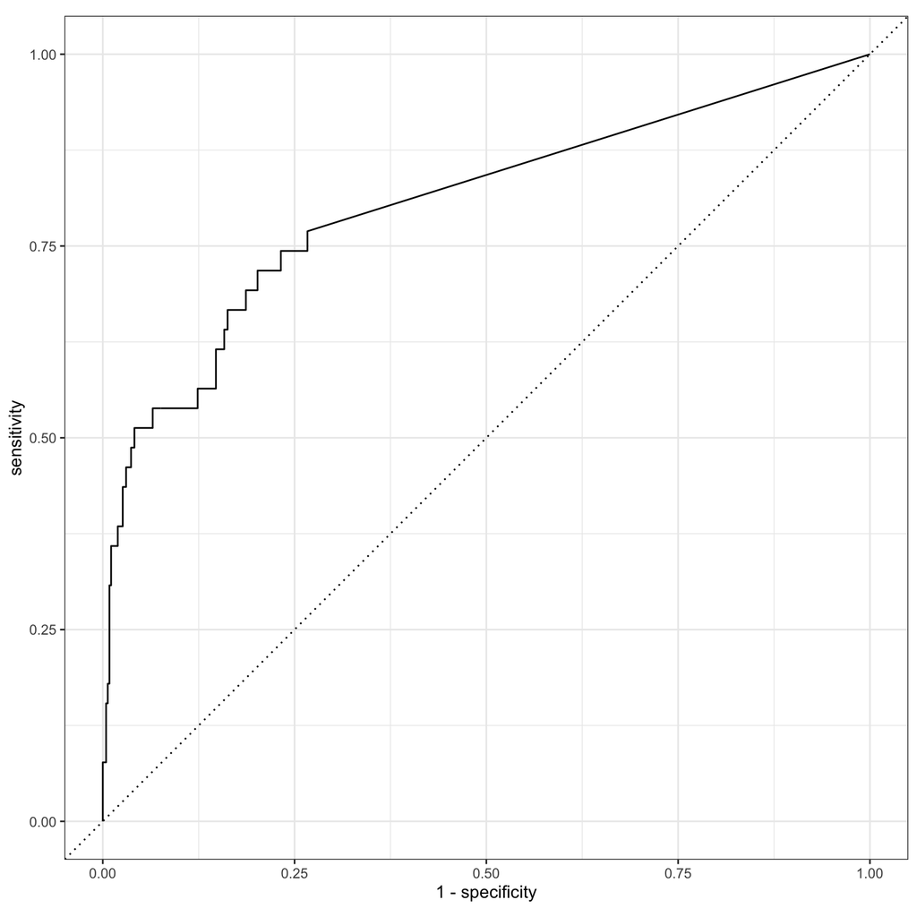

```r
roc_data <- prob_test %>% roc_curve(truth = children, .pred_children)
roc_data %>% autoplot()
```

# Computación en paralelo

Si queremos probar muchos modelos y/o nuestro volumen de datos es elevado, quizás nos lleve demasiado tiempo: vamos a hacer una incursión a la **programación paralelizada**.

```r
library(parallel)
library(doParallel)
```

Ambos paquetes serán los que nos permitan paralelizar de forma sencilla. La idea es **mandar tareas independientes a procesadores distintos**, de forma que si una tarea tarda 6 minutos en un pc, al mandarlo a otros dos procesadores, el tiempo pueda bajar hasta los 2 minutos (no es del todo lineal ya que hay un tiempo mínimo necesario en cada paso).

En muchas empresas u organismos de investigación se suele tener a disposición de los usuarios un conjunto de ordenadores (un clúster) común a todos de forma que cada persona pueda mandar sus hilos en paralelo. Pero…no tenemos de eso. ¿Entonces?

Vamos a **paralelizar en NUESTRO PROPIO ORDENADOR**: un ordenador suele tener **varios procesadores o cores** que pueden funcionar de manera «independiente» uno de otro. Vamos a detectar la cantidad de núcleos de los que podemos disponer con `detectCores()`.

```r
# Detectamos los cores que tenemos
detectCores()
```

```
[1] 8
```

A la hora de paralelizar es importante que lo hagamos con cuidado ya que puede que nuestro ordenador se quede colgado: mi consejo es que definas el número de cores a usar como los que tienes menos uno.

Con `makeCluster()` montamos los **clúster en cada nodo** y con `registerDoParallel()` registramos la paralelización (puedes ver los hilos abiertos con `showConnections()`).

```r
# Iniciamos la paralelización
clusters <- detectCores() - 1
make_cluster <- makeCluster(clusters)
registerDoParallel(make_cluster)
showConnections()
```

```
   description         class            mode  text     isopen
3  "output"            "textConnection" "wr"  "text"   "opened"
4  "<-localhost:11542" "sockconn"       "a+b" "binary" "opened"
5  "<-localhost:11542" "sockconn"       "a+b" "binary" "opened"
6  "<-localhost:11542" "sockconn"       "a+b" "binary" "opened"
7  "<-localhost:11542" "sockconn"       "a+b" "binary" "opened"
8  "<-localhost:11542" "sockconn"       "a+b" "binary" "opened"
9  "<-localhost:11542" "sockconn"       "a+b" "binary" "opened"
10 "<-localhost:11542" "sockconn"       "a+b" "binary" "opened"
   can read can write
3  "no"     "yes"
4  "yes"    "yes"
5  "yes"    "yes"
6  "yes"    "yes"
7  "yes"    "yes"
8  "yes"    "yes"
9  "yes"    "yes"
10 "yes"    "yes"
```

## Tuneado

El único cambio respecto a antes es indicarle `tune_grid()` que queremos la **validación paralelizada**, con `control = control_grid(allow_par = TRUE)`. Es importante que al **acabar la paralelización le indiquemos que cerramos los clúster**.

```r
hoteles_knn_fit_tune <-
 hoteles_wflow %>%
  tune_grid(resamples = hoteles_val, grid = grid_knn,
            control = control_grid(verbose = TRUE, allow_par = TRUE, #<<
                                   pkgs = c("outliers")),
            metrics = metric_set(accuracy, sensitivity, specificity, roc_auc))
# finalizamos clusters
stopCluster(make_cluster)
registerDoSEQ()

# Métricas
hoteles_knn_fit_tune %>% collect_metrics()
```

```
# A tibble: 72 × 9
       k weight    dist .metric   .esti…¹   mean     n std_err .config
   <int> <chr>    <dbl> <chr>     <chr>    <dbl> <int>   <dbl> <fct>
 1    10 gaussian   0.1 accuracy  binary  0.932      1      NA Prepro…
 2    10 gaussian   0.1 roc_auc   binary  0.764      1      NA Prepro…
 3    10 gaussian   0.1 sensitiv… binary  0.182      1      NA Prepro…
 4    10 gaussian   0.1 specific… binary  0.996      1      NA Prepro…
 5    55 gaussian   0.1 accuracy  binary  0.925      1      NA Prepro…
 6    55 gaussian   0.1 roc_auc   binary  0.830      1      NA Prepro…
 7    55 gaussian   0.1 sensitiv… binary  0.0568     1      NA Prepro…
 8    55 gaussian   0.1 specific… binary  0.999      1      NA Prepro…
 9   100 gaussian   0.1 accuracy  binary  0.922      1      NA Prepro…
10   100 gaussian   0.1 roc_auc   binary  0.852      1      NA Prepro…
# … with 62 more rows, and abbreviated variable name ¹.estimator
# ℹ Use `print(n = ...)` to see more rows
```

# Sobremuestreo/bajomuestreo

Un paso que hemos obviado: si tenemos la **variable objetivo desbalanceada** solo aprenderá de la clase mayoritaria. Este desbalanceamiento podemos mitigarlo realizando **sobremuestro/bajomuestreo**, añadiendo `step_upsample()` (del paquete `{themis}`) a la receta (el parámetro `over_ratio` nos cuantifica el % de la clase minoritaria entre la mayoritaria; si `over_ratio = 0.5`, implica que tenemos un 33% vs 66%).

```r
hoteles_rec_oversampling <-
  hoteles_rec %>%
  themis::step_upsample(children, over_ratio = 0.5)

bake(hoteles_rec_oversampling %>% prep(), new_data = NULL) %>%
  count(children) %>%
  mutate(porc = 100*n/sum(n))
```

```
# A tibble: 2 × 3
  children     n  porc
  <fct>    <int> <dbl>
1 children  2067  33.3
2 none      4135  66.7
```

Basta con repetir el proceso con la **receta con sobremuestreo**

```r
# Flujo de trabajo
hoteles_wflow_oversampling <-
  workflow() %>%
  add_recipe(hoteles_rec_oversampling) %>%
  add_model(knn_model_tune)

# Ajuste
hoteles_knn_fit_tune_oversampling <-
  hoteles_wflow_oversampling %>%
  tune_grid(resamples = hoteles_val, grid = grid_knn,
            control = control_grid(verbose = TRUE,
                                   allow_par = TRUE,
                                   pkgs = c("outliers")),
            metrics = metric_set(accuracy, sensitivity,
                                 specificity, roc_auc))
```

# Otras metodologías de validación